# Differential assembly diversifies GABA-A receptor structures and signaling

Andrija Sente

20/01/2022

This script reproduces the scRNAseq analysis used in the paper:

==============================================================================

**Differential assembly diversifies GABA-A receptor structures and signaling**

Andrija Sente1*, Rooma Desai2, Katerina Naydenova1, Tomas Malinauskas3, Youssef Jounaidi2, Jonas Miehling1, Xiaojuan Zhou2, Simonas Masiulis1,4, Steven W. Hardwick5, Dimitri Y. Chirgadze5, Keith W. Miller2*, A. Radu Aricescu1*

1 - MRC Laboratory of Molecular Biology, Francis Crick Avenue, Cambridge, CB2 0QH, UK.  
2 - Department of Anesthesia, Critical Care and Pain Medicine, Massachusetts General Hospital, Harvard Medical School, Boston, MA, USA.  
3 - Division of Structural Biology, Wellcome Centre for Human Genetics, University of Oxford, Roosevelt Drive, Oxford, OX3 7BN, UK.  
4 - Current address: Materials and Structural Analysis Division, Thermo Fisher Scientific, Achtseweg Noord, Eindhoven, 5651 GG, Netherlands.  
5 - Department of Biochemistry, University of Cambridge, Tennis Court Road, Cambridge, CB2 1GA, UK.

* - Correspondence to: asente@mrc-lmb.cam.ac.uk or k_miller@helix.mgh.harvard.edu or radu@mrc-lmb.cam.ac.uk

==============================================================================

This script generates panels for **Extended Data Figure 7a-b**

The trimmed_means.csv data used in the paper is available here: ftp://ftp.mrc-lmb.cam.ac.uk/pub/asente/differential-assembly/trimmed_means.csv

It is also downloadable from the following page: https://portal.brain-map.org/atlases-and-data/rnaseq/human-multiple-cortical-areas-smart-seq

If you use this data, please cite the following two papers: Hodge, R.D., Bakken, T.E., et al. (2019). “Conserved cell types with divergent features in human versus mouse cortex.” Nature 573:61-68.  
Tasic, B., et al. (2018). “Shared and distinct transcriptomic cell types across neocortical areas.” Nature 563(7729): 72-78. doi: 10.1038/s41586-018-0654-5. Epub 2018 Oct 31.

==============================================================================

```r
# Set up the environment
library(tidyverse)
library(pheatmap)
library(grid)
library('RColorBrewer')
require(dplyr)
require(UpSetR)
```

Set the threshold above which a gene is considered expressed.

```r
CPM_THRESHOLD <- 0
```

# Part 1: Plotting Extended Data Figure 7b

Load the trimmed means data

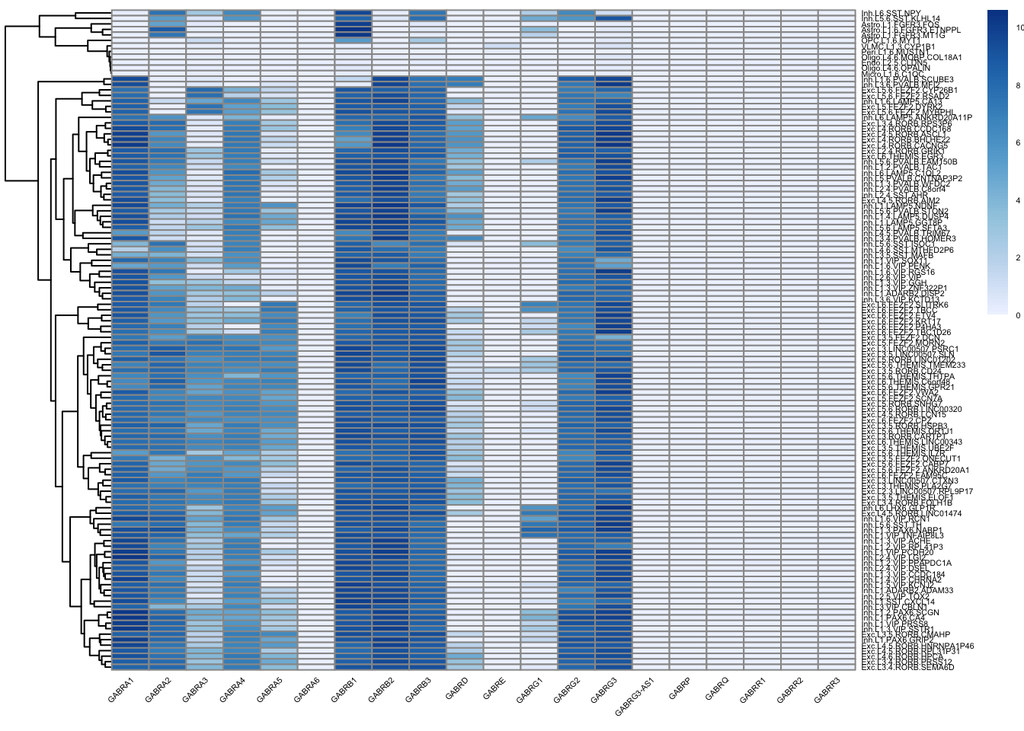

```r
trimmed_means <- read.csv('brain_map_allen/trimmed_means.csv',
                          stringsAsFactors = F, header = F)
trimmed_means <- as.data.frame(trimmed_means)
new_names <- make.names(trimmed_means[1, ])
colnames(trimmed_means) <- new_names
trimmed_means <- trimmed_means[-1, ]

# Find rows with GABAA receptor genes
gaba_trimmed_means <- trimmed_means[grep(trimmed_means$X, pattern = 'GABR'), ]
rownames(gaba_trimmed_means) <- gaba_trimmed_means$X
gaba_trimmed_means$X <- NULL
rows <- rownames(gaba_trimmed_means)

# Convert CPMs to numeric.
gaba_trimmed_means <- mutate_all(gaba_trimmed_means,
                                 function(x) as.numeric(as.character(x)))

# Add rownames
rownames(gaba_trimmed_means) <- rows

# Plot heatmap of trimmed mean counts (Extended Data Figure 7b)
heatmap_plot <- pheatmap(mat = as.matrix(t(gaba_trimmed_means)),
                         cluster_cols = F, fontsize = 4,
                         color = colorRampPalette(brewer.pal(n = 7, name = "Blues"))(100),
                         angle_col = '45')
```

# Part 2: Plotting Extended Data Figure 7a

Binarize and transpose the data frame:

```r
gaba_trimmed_means_binarized <- mutate_all(gaba_trimmed_means,
                                           function(x) {ifelse(x > CPM_THRESHOLD, 1, 0)})
rownames(gaba_trimmed_means_binarized) <- rows
gaba_upsetR <- as.data.frame(t(gaba_trimmed_means_binarized))
colnames(gaba_upsetR) <- rows
```

Plot Extended Data Figure 7a:

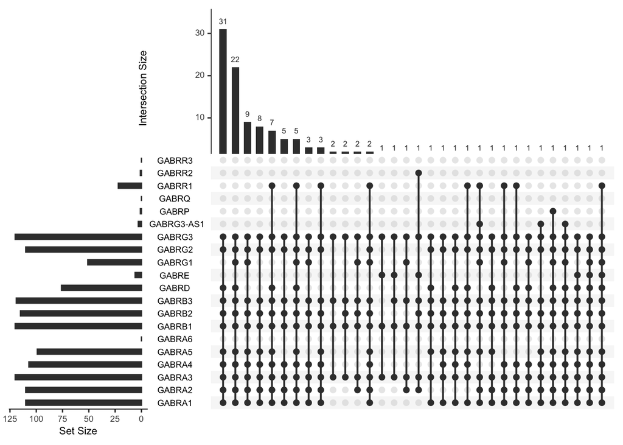

```r
upset_plot <- upset(gaba_upsetR, sets = rows,
                    order.by = c('freq'), mb.ratio = c(0.35, 0.65),
                    keep.order = T, nintersects = NA)
upset_plot
```

Save the plots:

```r
# pdf('~/Dropbox/lab-notes/extrasynaptic-manuscript/Figures/bioinformatics/RNAseq-heatmap.pdf',
#     width = 8, height = 8, onefile = F) # onefile avoids printing on two pdf pages - upsetR bug?
# print(heatmap_plot)
# dev.off()
#
# pdf('~/Dropbox/lab-notes/extrasynaptic-manuscript/Figures/bioinformatics/RNAseq-heatmap-new.pdf',
#     width = 6.6, height = 6.6, onefile = F) # onefile avoids printing on two pdf pages - upsetR bug?
# print(heatmap_plot)
# dev.off()
```